# Supervised Learning III

Ranking Features by Feature Filters

# Goals

Learn how to rank features of a supervised task by their importance / strength of relationship with the target variable using a feature filter method.

# German Credit Dataset

We create the task as for the resampling exercise: Again, we make us of our work horse: The German Credit Data set.

```r
library("mlr3verse")
library("data.table")
task = tsk("german_credit")
```

# Exercises

## Exercise 1: Find a suitable Feature Filter

Make yourself familiar with the `mlr3filters` package ([link](https://mlr3filters.mlr-org.com/)). Which `Filter`s are applicable to all feature types from the task we created above?

**Hint:**

Some filters are only applicable to either classification or regression or either numeric or categorical features. Therefore, we are looking for a `Filter` that is applicable to our classification task and that can be computed for `integer` and `factor` features (as these types of features are present in task, see `task$feature_types`).

The website linked above includes a table that provides detailed information for each `Filter`.

### Solution:

**Click me:**

Our task is a classification task and we have `integer`, and `factor` and features:

```r
task$task_type
```

```
## [1] "classif"
```

```r
ftypes = unique(task$feature_types$type)
ftypes
```

```
## [1] "integer" "factor"  "ordered"
```

```r
# subset all filters that support integer and factor features
library(mlr3filters)
filters = as.data.table(mlr_filters)
check_ftypes = sapply(filters$feature_types, function(x) all(ftypes %in% x))
filters[check_ftypes, ]
```

```
##                   key                                                    label   task_types task_properties
##  1:              cmim      Minimal Conditional Mutual Information Maximization classif,regr
##  2:              disr                       Double Input Symmetrical Relevance classif,regr
##  3:        importance                                         Importance Score      classif
##  4:  information_gain                                         Information Gain classif,regr
##  5:               jmi                                 Joint Mutual Information classif,regr
##  6:              jmim            Minimal Joint Mutual Information Maximization classif,regr
##  7:               mim                          Mutual Information Maximization classif,regr
##  8:              mrmr                     Minimum Redundancy Maximal Relevancy classif,regr
##  9:             njmim Minimal Normalised Joint Mutual Information Maximization classif,regr
## 10:       performance                                   Predictive Performance      classif
## 11:       permutation                                        Permutation Score      classif
## 12:            relief                                                   RELIEF classif,regr
## 13: selected_features                               Embedded Feature Selection      classif
##                              params                                        feature_types          packages
##  1:                         threads                       integer,numeric,factor,ordered           praznik
##  2:                         threads                       integer,numeric,factor,ordered           praznik
##  3:                          method logical,integer,numeric,character,factor,ordered,...              mlr3
##  4: type,equal,discIntegers,threads                       integer,numeric,factor,ordered     FSelectorRcpp
##  5:                         threads                       integer,numeric,factor,ordered           praznik
##  6:                         threads                       integer,numeric,factor,ordered           praznik
##  7:                         threads                       integer,numeric,factor,ordered           praznik
##  8:                         threads                       integer,numeric,factor,ordered           praznik
##  9:                         threads                       integer,numeric,factor,ordered           praznik
## 10:                          method logical,integer,numeric,character,factor,ordered,... mlr3,mlr3measures
## 11:                 standardize,nmc logical,integer,numeric,character,factor,ordered,... mlr3,mlr3measures
## 12:      neighboursCount,sampleSize                       integer,numeric,factor,ordered     FSelectorRcpp
## 13:                          method logical,integer,numeric,character,factor,ordered,...              mlr3
```

Looking at the table [here](https://mlr3filters.mlr-org.com/), potential filters are:

`cmim`, `disr`, `importance`, `information_gain`, `jmi`, `jmim`, `mim`, `mrmr`, `njmim`, `performance`, `permutation`, `relief`, `selected_features`.

You can read their documentation by looking at `?mlr_filters_<id>`, (`<id>` should be replaced with the filter id, e.g., `cmim`).

Note that `importance`, `performance`, `permutation`, and `selected_features` are special in the sense that they require `Learner`s themselves.

## Exercise 2: Information Gain Filter

We now want to use the `information_gain` filter which requires to install the `FSelectorRcpp` package. This filter quantifies the gain in information by considering the following difference: `H(Target) + H(Feature) - H(Target, Feature)` Here, `H(X)` is the Shannon entropy for variable `X` and `H(X, Y)` is the joint Shannon entropy for variable `X` conditioned on `Y`.

Create an information gain filter and compute the information gain for each feature.

Visualize the score for each feature and decide how many and which features to include.

**Hint 1:**

Use `flt("information_gain")` to create an `information_gain` filter and calculate the filter scores of the features. See `?mlr_filters_information_gain` (or equivalently `flt("information_gain")$help()`) for more details on how to use a filter. If it does not work, you can use e.g. `flt("importance", learner = lrn("classif.rpart"))` which uses the feature importance of a `classif.rpart` decision tree to rank the features for the feature filter.

For visualization, you can, for example, create a scree plot (similar as in principle component analysis) that plots the filter score for each feature on the y-axis and the features on the x-axis.

Using a rule of thumb, e.g., the ‘’elbow rule’’ you can determine the number of features to include.

**Hint 2:**

```r
library(mlr3filters)
library(mlr3viz)
filter = flt(...)
filter$calculate()
autoplot(...)
```

### Solution:

**Click me:**

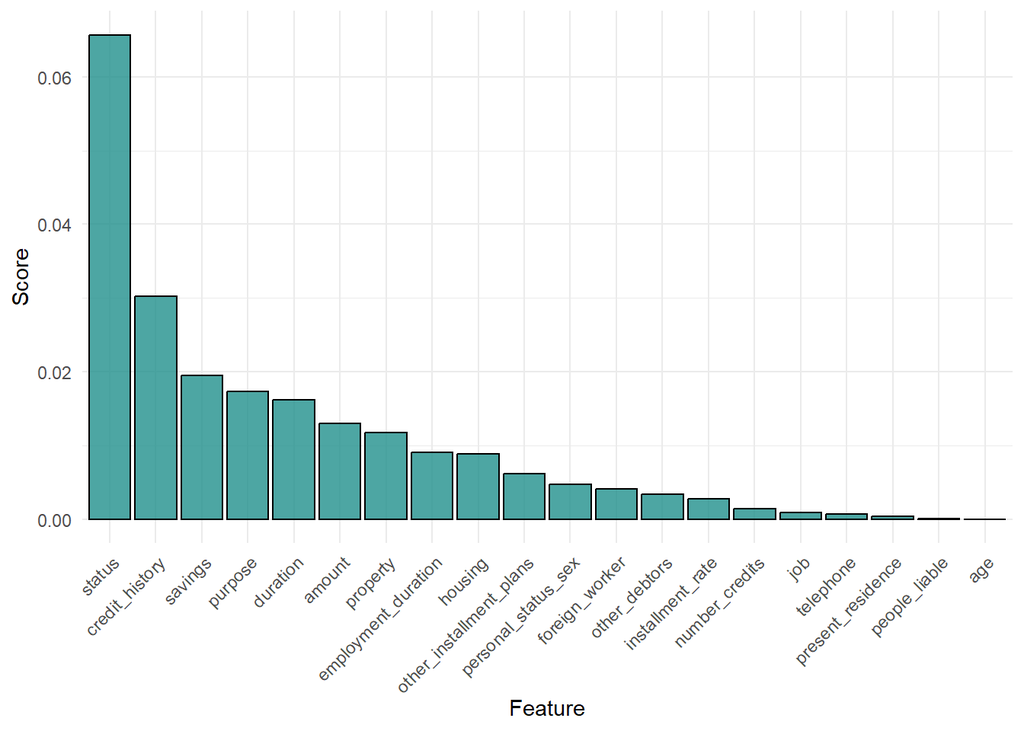

```r
library(mlr3filters)
library(mlr3viz)
filter = flt("information_gain")
filter$calculate(task)
autoplot(filter)  # status, credit_history and savings
```

## Exercise 3: Create and Apply a PipeOpFilter to a Task

Since the k-NN learner suffers from the curse of dimensionality, we want set up a preprocessing `PipeOp` to subset our set of features to the 5 most important ones according to the information gain filter (see `flt("information_gain")$help()`). In general, you can see a list of other possible filters by looking at the dictionary `as.data.table(mlr_filters)`. You can construct a `PipeOp` object with the `po()` function from the `mlr3pipelines` package. See `mlr_pipeops$keys()` for possible choices. Create a `PipeOp` that filters features of the `german_credit` task and creates a new task containing only the 5 most important ones according to the information gain filter.

**Hint 1:**

- The filter can be created by `flt("information_gain")` (see also the help page `flt("information_gain")$help()`).
- In our case, we have to pass the `"filter"` key to the first argument of the `po()` function and the filter previously created with the `flt` function to the `filter` argument of the `po()` function to construct a `PipeOpFilter` object that performs feature filtering (see also code examples in the help page `?PipeOpFilter`).
- The help page of `?PipeOpFilter` also reveals the parameters we can specify. For example, to select the 5 most important features, we can set `filter.nfeat`. This can be done using the `param_vals` argument of the `po()` function during construction or by adding the parameter value to the `param_set$values` field of an already created `PipeOpFilter` object (see also code examples in the help page).
- The created `PipeOpFilter` object can be applied to a `Task` object to create the filtered `Task`. To do so, we can use the `$train(input)` field of the `PipeOpFilter` object and pass a **list** containing the task we want to filter.

**Hint 2:**

```r
library(mlr3pipelines)
# Set the filter.nfeat parameter directly when constructing the PipeOp:
pofilter = po("...",
  filter = flt(...),
   ... = list(filter.nfeat = ...))

# Alternative (first create the filter PipeOp and then set the parameter):
pofilter = po("...", filter = flt(...))
pofilter$...$filter.nfeat = ...

# Train the PipeOpFilter on the task
filtered_task = pofilter$train(input = list(...))
filtered_task
task
```

### Solution:

**Click me:**

```r
library(mlr3pipelines)
# Set the filter.nfeat parameter directly when constructing the PipeOp:
pofilter = po("filter",
  filter = flt("information_gain"),
   param_vals = list(filter.nfeat = 5L))

# Alternative (first create the filter PipeOp and then set the parameter):
pofilter = po("filter", filter = flt("information_gain"))
pofilter$param_set$values$filter.nfeat = 5L

filtered_task = pofilter$train(list(task))[[1]]
filtered_task
```

```
## <TaskClassif:german_credit> (1000 x 6): German Credit
## * Target: credit_risk
## * Properties: twoclass
## * Features (5):
##   - fct (4): credit_history, purpose, savings, status
##   - int (1): duration
```

```r
task
```

```
## <TaskClassif:german_credit> (1000 x 21): German Credit
## * Target: credit_risk
## * Properties: twoclass
## * Features (20):
##   - fct (14): credit_history, employment_duration, foreign_worker, housing, job, other_debtors,
##     other_installment_plans, people_liable, personal_status_sex, property, purpose, savings, status,
##     telephone
##   - int (3): age, amount, duration
##   - ord (3): installment_rate, number_credits, present_residence
```

## Exercise 4: Combine PipeOpFilter with a Learner

Do the following tasks:

1. Combine the `PipeOpFilter` from the previous exercise with a k-NN learner to create a so-called `Graph` (it can contain multiple preprocessing steps) using the `%>>%` operator.
2. Convert the `Graph` to a `GraphLearner` so that it behaves like a new learner that first does feature filtering and then trains a model on the filtered data and run the `resample()` function to estimate the performance of the `GraphLearner` with a 5-fold cross-validation.
3. Change the value of the `nfeat.filter` parameter (which was set to 5 in the previous exercise) and run again `resample()`.

**Hint 1:**

- Create a kNN learner using `lrn()`. Remember that the shortcut for a kNN classifier ist `"classif.kknn"`.
- You can concatenate different preprocessing steps and a learner using the `%>>%` operator.
- Use `as_learner` to create a `GraphLearner` (see also the code examples in the help page `?GraphLearner`).

**Hint 2:**

```r
library(mlr3learners)
graph = ... %>>% lrn("...")
glrn = as_learner(...)
rr = resample(task = ..., learner = ..., resampling = ...)
rr$aggregate()

# Change `nfeat.filter` and run resampling again using same train-test splits
...
rr2 = resample(task = ..., learner = ..., resampling = rr$resampling)
rr2$aggregate()
```

### Solution:

**Click me:**

```r
set.seed(1)
library(mlr3learners)
graph = pofilter %>>% lrn("classif.kknn")
glrn = as_learner(graph)
rr = resample(task = task, learner = glrn, resampling = rsmp("cv", folds = 5))
rr$aggregate()
```

```
## classif.ce
##      0.271
```

```r
# Change `nfeat.filter` and run resampling again using same train-test splits
glrn$param_set$values$information_gain.filter.nfeat = 2
rr2 = resample(task = task, learner = glrn, resampling = rr$resampling)
rr2$aggregate()
```

```
## classif.ce
##      0.286
```

# Summary

We learned how to use feature filters to rank the features w.r.t. a feature filter method in a supervised setting and how to subset a task accordingly.

Ideally, feature filtering is directly incorporated into the learning procedure by making use of a pipeline so that performance estimation after feature filtering is not biased.